# Qüestionari 2

# Pregunta 1

El paquet `nycflights13` conté informació dels vols que van sortir de Nova York l’any 2013. Un cop instal·lat el paquet, la instrucció `data(package = 'nycflights13')` permet veure les taules que conté. Si carreguem el paquet amb la funció `library()`, podrem utilitzar les taules.

A la taula `flights` disposem d’informació dels vols que van sortir de Nova York. Podem obtenir més informació d’aquesta taula amb l’ajuda d’R (`help(flights)`).

Per a totes les preguntes del qüestionari, ompliu els espais amb la resposta adequada.

1. Considerant els vols que surten de Nova York amb destinació als aeroports amb codi “BOS” o “SFO”, quina proporció (**tant per u**) de vols provenen de l’aeroport Internacional de Newark Liberty (EWR)? (per respondre aquestes preguntes utilitzeu les columnes `origin` i `dest`)
2. Quina és la mediana del retard, en minuts, dels vols que surten de l’aeroport Internacional de Newark Liberty (EWR) amb destinació a l’aeroport amb codi “BOS”? (utilitzeu la variable `dep_delay`)
3. El retard dels vols que surten de l’aeroport Internacional de Newark Liberty (EWR) amb destinació a l’aeroport amb codi “BOS” tenen biaix. Cap a on és aquest biaix? (possibles respostes: `dreta` o `esquerra`)
4. Quina és la correlació entre el retard en la sortida (`dep_delay`) i el retard en l’arribada (`arr_delay`) dels vols que surten de l’aeroport Internacional de Newark Liberty (EWR) amb destinació a l’aeroport amb codi “BOS”?

## Resposta

Primerament carregarem el paquet `nycflights13` i els altres paquets necessaris:

```r
library(nycflights13)
library(tidyverse)
```

1. Per trobar la proporció indicada, filtrarem els vols amb destinació `DEST`, i mirarem quina proporció de vols provenen de l’aeroport `ORIG`:

```r
ORIG = "EWR"
DEST = c("BOS", "SFO")

flights %>%
  filter(dest %in% DEST) %>%
  summarise(
    p = mean(origin == ORIG)
  )
# > # A tibble: 1 x 1
# >       p
# >   <dbl>
# > 1 0.362
```

2. Depenen de si se us demana la mitjana o la mediana, caldrà canviar la definició de la funció `f_estad`. En aquest cas hem de filtrar els vols demanats, vols que surten de `ORIG` i que tenen destinació el primer element del vector `DEST`.

```r
f_estad = median
flights %>%
  filter(origin == ORIG, dest == DEST[1]) %>%
  summarise(
    value = f_estad(dep_delay, na.rm=TRUE)
  )
# > # A tibble: 1 x 1
# >   value
# >   <dbl>
# > 1    -2
```

3. En aquesta cas, per la natura de la variable, és fàcil veure que el retard té un fort biaix a la **dreta**. Podem veure-ho veient que la mitjana és bastant superior a la mediana.

```r
flights %>%
  filter(origin == ORIG, dest == DEST[1]) %>%
  summarise(
    mean_ = mean(dep_delay, na.rm=TRUE),
    median_ = median(dep_delay, na.rm=TRUE)
  )
# > # A tibble: 1 x 2
# >   mean_ median_
# >   <dbl>   <dbl>
# > 1  12.5      -2
```

4. Per calcular la correlació, filtrarem els vols demanats i calcularem la correlació. En aquest cas, és necessari eliminar el valors perduts. Per fer-ho, cal indicar-ho amb el paràmetre `use` de la funció `cor()`.

```r
flights %>%
  filter(origin == ORIG, dest == DEST[1]) %>%
  summarise(
    value = cor(dep_delay, arr_delay, use = "complete.obs")
  )
# > # A tibble: 1 x 1
# >   value
# >   <dbl>
# > 1 0.952
```

# Pregunta 2

Descarregueu el fitxer pokemon.csv. Aquest arxiu de text amb format csv conté una llista de Pokemon amb les seves habilitats i característiques. Podeu trobar més informació sobre les variables d’aquest conjunt de dades a l’adreça https://www.kaggle.com/takamasakato/pokemon-all-status-data.

Per a totes les preguntes del qüestionari, ompliu els espais amb la resposta adequada.

1. Quants Pokemon existeixen de tipus 1 “Bug” i tipus 2 “Grass”?
2. Treballant amb els Pokemon de tipus 1 “Poison”. Per a quin grup definit pels valors de la variable `GENERATION` s’obté que la variable de defensa física (`DEF`) té un coeficient de variació més elevat?
3. De les següents possibilitats pel tipus 1 de Pokemon: `Fire, Fighting, Ground`. Quin s’ha utilitzat per fer el següent gràfic de caixa que descriu la variable de defensa física (`DEF`)?

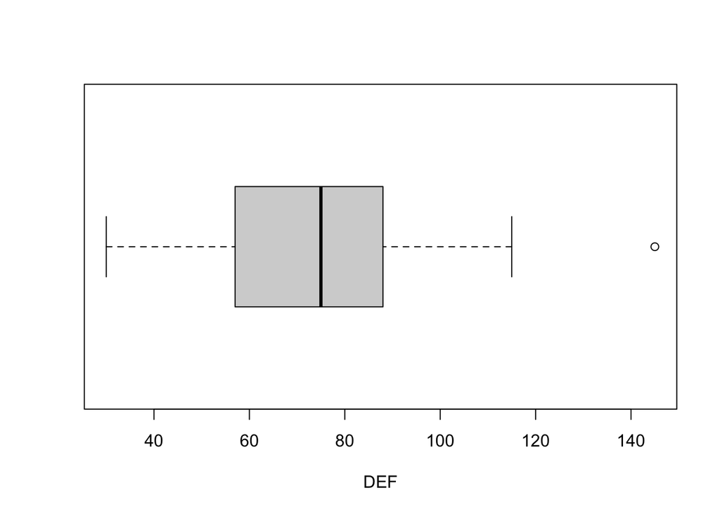

## Resposta

Primerament carregarem el conjunt Pokemon:

```r
pokemon = read_csv("quest-2-pokemon.csv")
```

1. Filtrem els tipus de Pokemon demanats i comptem el nombre de files de la taula obtinguda.

```r
TYPE1_ = "Bug"
TYPE2_ = "Grass"
pokemon %>%
  filter(TYPE1 == TYPE1_, TYPE2 == TYPE2_) %>%
  nrow()
# > [1] 6
```

2. Primerament filtrarem per la condició `TYPE == TYPE_`. Després, per cada valor possible de la variable `GENERATION`, calcularem el coeficient de variació per la variable `DEF` (caldrà modificar-ho per `ATK` en cas que es demani atac). Ordenarem per detectar el que té la major variació.

```r
TYPE_ = "Poison"
pokemon %>%
  filter(TYPE1 == TYPE_) %>%
  group_by(GENERATION) %>%
  summarise(.groups = 'drop',
            n = n(),
            cv = sd(DEF, na.rm=TRUE) / mean(DEF, na.rm=TRUE)    # Cal possar DEF o ATK
  ) %>%
  arrange(desc(cv))
# > # A tibble: 8 x 3
# >   GENERATION     n     cv
# >        <dbl> <int>  <dbl>
# > 1          7     8  0.472
# > 2          4     6  0.377
# > 3          1    14  0.348
# > 4          6     2  0.283
# > 5          3     3  0.240
# > 6          5     2  0.196
# > 7          8     3  0.140
# > 8          2     1 NA
```

3. Comparant els diferents resultats, podem veure que s’ha utilitzat el tipus `Fighting`:

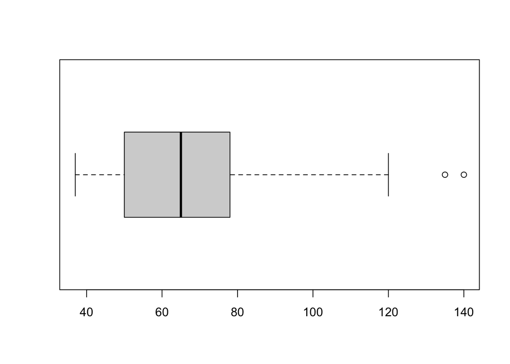

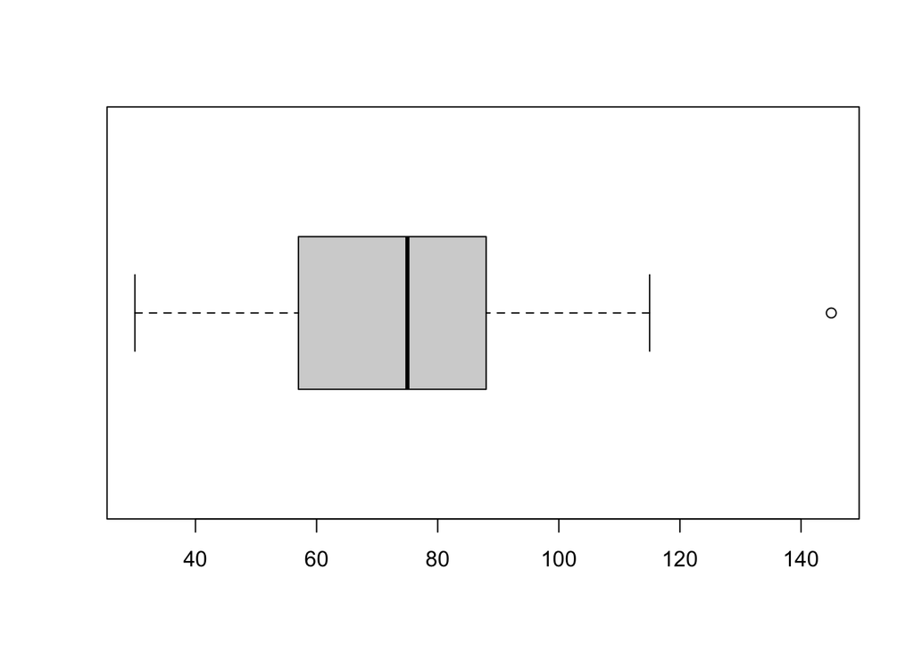

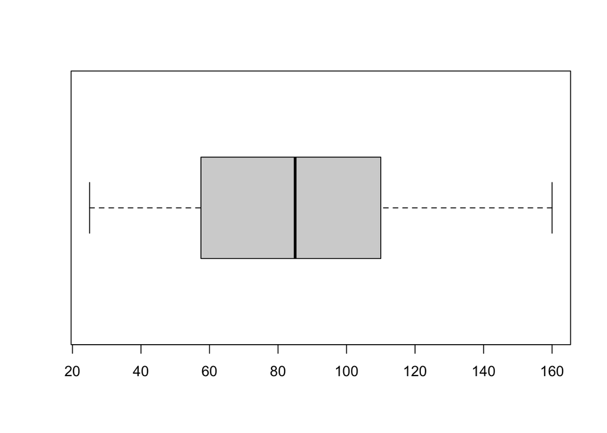

```r
with(filter(pokemon, TYPE1 == 'Fire'), boxplot(DEF, horizontal = TRUE))
with(filter(pokemon, TYPE1 == 'Fighting'), boxplot(DEF, horizontal = TRUE))
with(filter(pokemon, TYPE1 == 'Ground'), boxplot(DEF, horizontal = TRUE))
```

# Pregunta 3

A https://github.com/owid/covid-19-data/tree/master/public/data trobareu informació sobre registres de COVID 19 a diferents parts del món. Com que cada dia actualitzen la informació, nosaltres treballarem amb la versió del dia 14 d’octubre, disponible en el següent enllaç owid-covid-data.csv. Trobareu informació sobre el conjunt descarregat a https://ourworldindata.org/coronavirus-source-data.

Per carregar l’arxiu `owid-covid-data.csv` amb format correcte, quan crideu a la funció `read_csv()`, **passeu el següent objecte com a paràmetre `col_types`**:

```r
format_columnes = cols(
  .default = col_double(),
  iso_code = col_character(),
  continent = col_character(),
  location = col_character(),
  date = col_date(format = ""),
  tests_units = col_character())
```

La crida quedarà de la següent manera: `read_csv(<adreça de l'arxiu>, col_type = format_columnes)`.

Per aquest qüestionari necessitareu **crear una nova columna anomenada `month`** (ajuda’t de la funció `mutate()` per crear la nova variable). Aquesta nova variable la podreu crear amb la funció `month()` del paquet `lubridate`. Aquesta llibreria està inclosa a `tidverse`, però no es carrega per defecte, caldrà carregar-la. Donada una data (per exemple la columna `date`), la funció `month()` retorna el mes de la data.

Finalment, caldrà que **filtreu la taula amb les observacions d’aquest any 2020** (de manera similar a la funció `month()`, podreu utilitzar la funció `year()` per extreure l’any d’una data).

Per a totes les preguntes del qüestionari, ompliu els espais amb la resposta adequada.

1. Quantes observacions té la taula importada després de filtrar les observacions de l’any 2020?
2. Quin és el número de mes amb més morts per COVID-19 (utilitza la variable `new_deaths) a Grècia (“Greece”)?
3. Estem interessats a estudiar la relació entre els nous testos i els nous casos. A quin dels següents païssos pertany el següent gràfic: Austria, Italy, Greece, France, Portugal

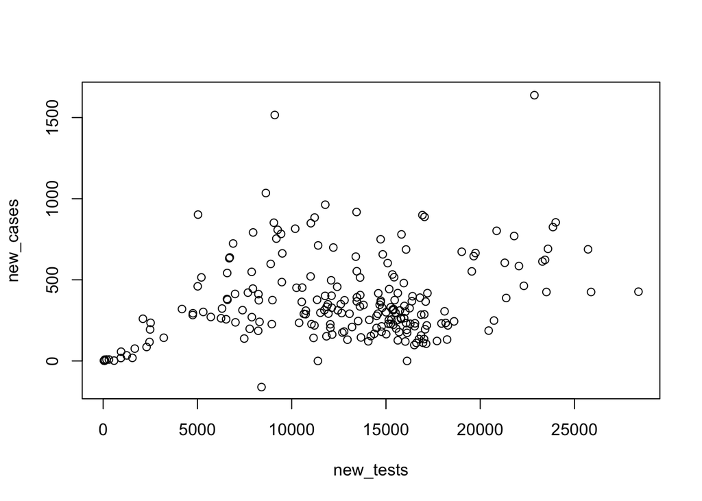

## Resposta

Primerament descarreguem i carreguem les dades demanades:

```r
commit = "46848f81eee15ba0d64c47e3f10eb8fbaf40bb27"
fname = "owid-covid-data.csv"
url_covid = sprintf("https://raw.githubusercontent.com/owid/covid-19-data/%s/public/data/%s",
                    commit, fname)
covid = read_csv(url_covid,
                 col_types = cols(
                   .default = col_double(),
                   iso_code = col_character(),
                   continent = col_character(),
                   location = col_character(),
                   date = col_date(format = ""),
                   tests_units = col_character()))

data = covid %>%
  mutate(year = year(date),
         month = month(date)) %>%
  filter(year == 2020)
```

```r
nrow(data)
# > [1] 50022
```

```r
LOCATION = "Greece"
data %>%
  filter(location == LOCATION) %>%
  group_by(month) %>%
  summarise(
    total = sum(new_tests, na.rm=TRUE) # new_cases, new_tests, new_deaths
  ) %>%
  arrange(desc(total))
# > `summarise()` ungrouping output (override with `.groups` argument)
# > # A tibble: 10 x 2
# >    month  total
# >    <dbl>  <dbl>
# >  1     8 347062
# >  2     9 198679
# >  3     7 195937
# >  4    10 122121
# >  5     5 105348
# >  6     6  82158
# >  7     4  53426
# >  8     3   8718
# >  9     1      0
# > 10     2      0
```

3. Veient els gràfics veiem que el gràfic es va fer utilitzant Portugal.

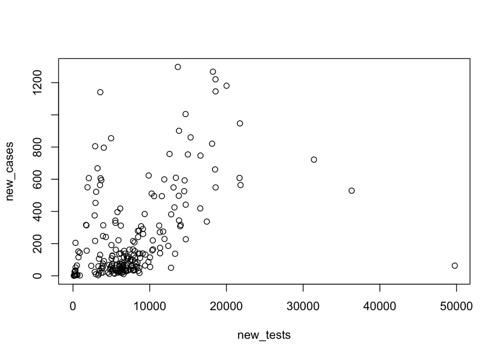

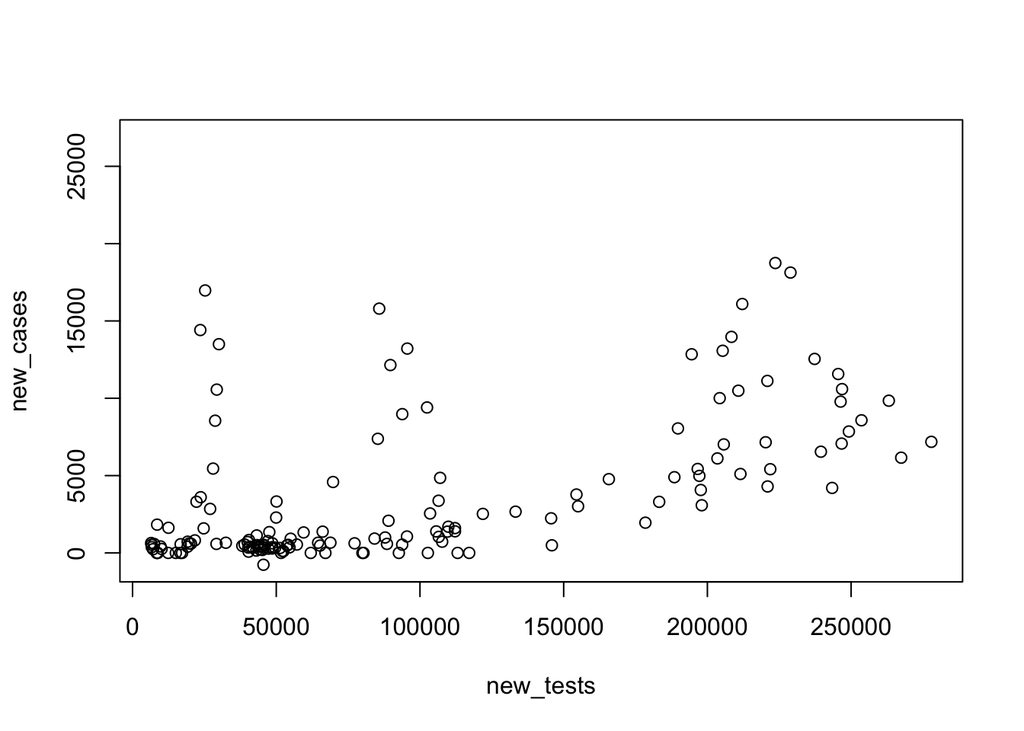

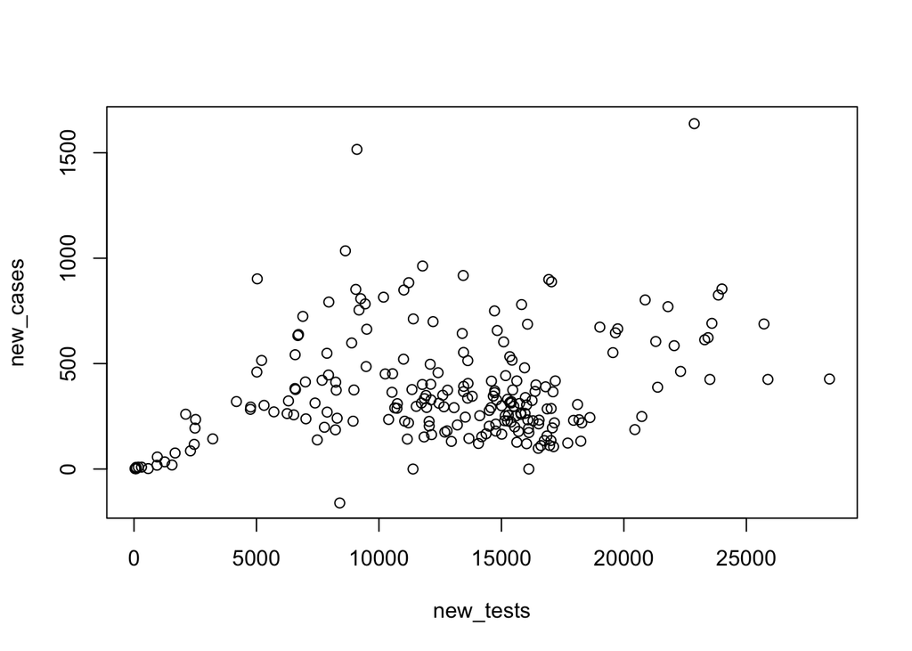

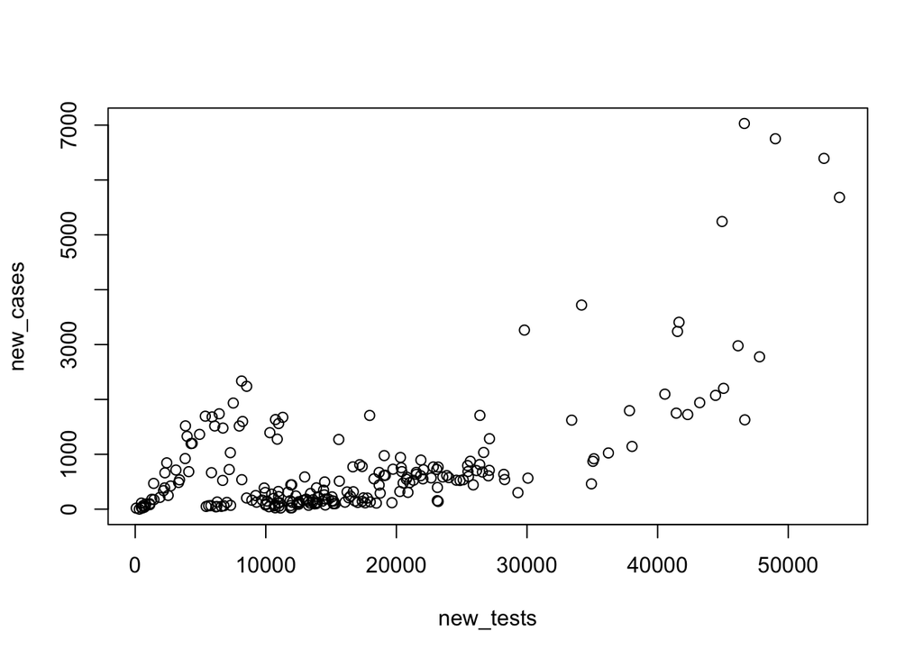

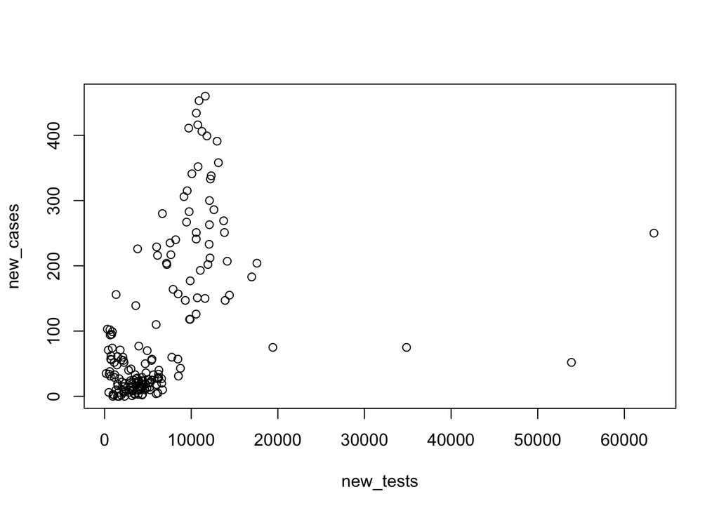

```r
with(filter(data, location == 'Austria'), plot(new_tests, new_cases))
with(filter(data, location == 'France'), plot(new_tests, new_cases))
with(filter(data, location == 'Portugal'), plot(new_tests, new_cases))
with(filter(data, location == 'Belgium'), plot(new_tests, new_cases))
with(filter(data, location == 'Greece'), plot(new_tests, new_cases))
```